# HW3

資二B 09156257 張芷瑜

資料來源:政府資料開放平台  
https://data.gov.tw/dataset/13126  
https://data.gov.tw/dataset/131739

### 前言

從過去到現在台灣大學的數量及入學方式有了許多的改變,因此我們想要探討這些改變是否使升學率有所改變

補充:  
民國50年代開始為配合經濟建設,高等教育成為發展重點  
民國57年開始實施九年義務教育  
民國61~72年為舊制聯考  
民國73~90年為新制聯考  
民國75年為一個大學數量大概的分界  
91學年度全面實施多元入學  
民國95年開始繁星計畫

### 解題

```r
#讀檔
data=read.csv("C:\\Users\\User\\Desktop\\統計\\ggg.csv")
a=data.frame(
  year=c(data$年度),
  rate=c(data$升學率)
  )

result=aov(rate~year,data=a) #計算ANOVA表
summary(result) #印出ANOVA概要
```

```
##             Df Sum Sq Mean Sq F value   Pr(>F)
## year         3 0.8139 0.27130   56.28 9.55e-16 ***
## Residuals   48 0.2314 0.00482
## ---
## Signif. codes:  0 '***' 0.001 '**' 0.01 '*' 0.05 '.' 0.1 ' ' 1
```

拒絕域:$F>F_{\alpha,k-1,n-k}$  
假設$\alpha=0.05$  
$F>F_{0.05,3,48} \approx F_{0.05,3,50}=2.79$  
拒絕$H_0$  
$p-value為9.55 \times 10^{-16}有壓倒性的證據證明這四個區間的平均數至少有兩個不同$

從此圖可以看出四個區間的分布

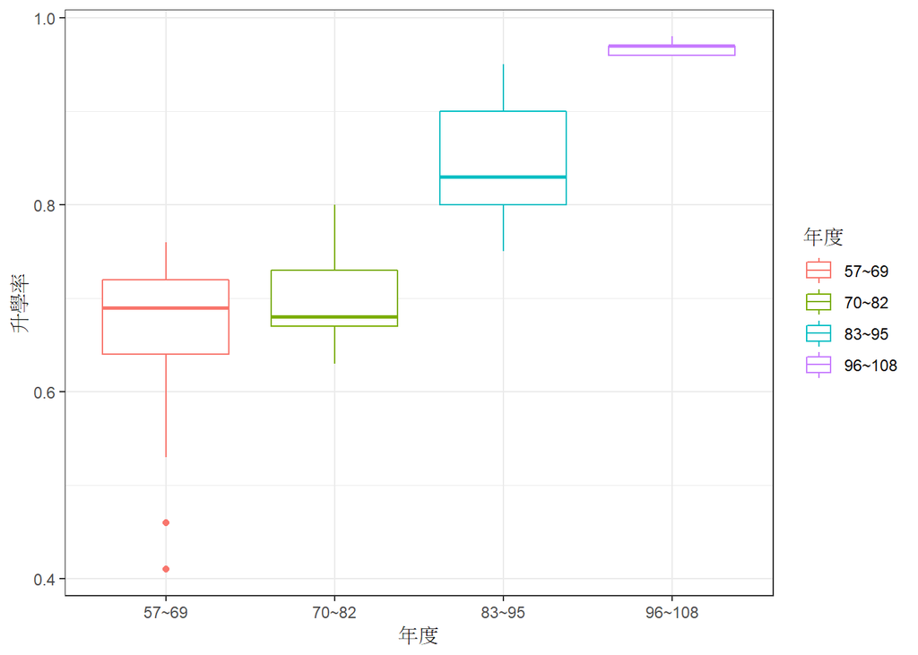

```r
library(ggplot2)
a=read.csv("C:\\Users\\User\\Desktop\\統計\\ggg.csv") #讀檔
p=ggplot(a,aes(x=年度,y=升學率))
p+geom_boxplot(data=a,aes(color=年度))+theme_bw() #繪圖
```

接著我們想要決定升學率跟年度之間的直線關係 驗證線性關係: $H_0:\beta_1=0$  
$H_1:\beta_1 \neq 0$

```r
#讀檔
d=read.csv("C:\\Users\\User\\Desktop\\統計\\ooo.csv")
e=data.frame(
  year=c(d$年度),
  rate=c(d$升學率)
  )

n=52 #資料總數
a=0.05 #信心水準
#計算
x=sum(e$year)
y=sum(e$rate)
x2=sum(e$year^2)
y2=sum(e$rate^2)
xy=sum(e$year*e$rate)
sxy=(1/(n-1))*(xy-((x-y)/n))
sx2=(1/(n-1))*(x2-((x^2)/n))
sy2=(1/(n-1))*(y2-((y^2)/n))
xb=x/n
yb=y/n

#迴歸直線
b1=sxy/sx2
b0=yb-b1*xb

#檢驗線性關係
sse=(n-1)*(sy2-((sxy^2)/sx2))
se=sqrt(abs(sse/(n-2)))
sb1=se/(sqrt((n-1)*sx2))
t=(b1-0)/sb1 #t值
tt=qt(a/2,n-2) #拒絕域
#印出值
t
tt
-tt
b0
b1
sse
```

```
## [1] 7.074783
## [1] -2.008559
## [1] 2.008559
## [1] -23.25871
## [1] 0.2915181
## [1] -994.3583
```

```r
#讀檔
b=read.csv("C:\\Users\\User\\Desktop\\統計\\ooo.csv")
c=data.frame(
  year=c(b$年度),
  rate=c(b$升學率)
  )

q=lm(rate~year,data=c) #訓練關係模型
summary(q) #印出關係概要
```

```
##
## Call:
## lm(formula = rate ~ year, data = c)
##
## Residuals:
##       Min        1Q    Median        3Q       Max
## -0.179783 -0.036989 -0.000416  0.037900  0.144461
##
## Coefficients:
##              Estimate Std. Error t value Pr(>|t|)
## (Intercept) 0.0832485  0.0467374   1.781    0.081 .
## year        0.0085853  0.0005574  15.403   <2e-16 ***
## ---
## Signif. codes:  0 '***' 0.001 '**' 0.01 '*' 0.05 '.' 0.1 ' ' 1
##
## Residual standard error: 0.06032 on 50 degrees of freedom
## Multiple R-squared:  0.8259, Adjusted R-squared:  0.8225
## F-statistic: 237.3 on 1 and 50 DF,  p-value: < 2.2e-16
```

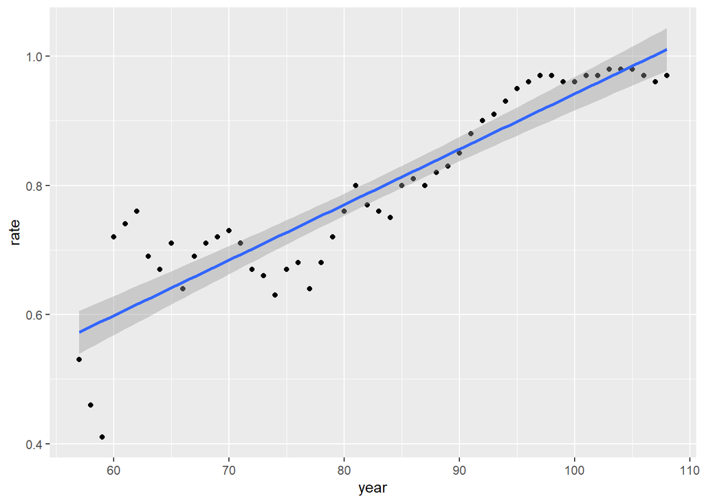

```r
ggplot(c,aes(x=year,y=rate))+geom_point()+geom_smooth(method=lm) #繪圖
```

### 發現問題

我們發現關係模型算出來的迴歸直線方程式與與依照課本所算出來的結果不太吻合,因此需要更多時間去研究這個部分

### 結論

1.從變異數分析中可以看出四個年代區間的平均數至少有兩個是不同的,代表教育政策的改革對大學的升學率是有影響  
2.在線性迴歸的部分可以看出年代與升學率的是正相關  
綜合上面兩點得出的結論為隨著教育不斷的改革,升學率也一同增長

### 參考資料

文獻  
https://zh.wikipedia.org/wiki/%E5%A4%A7%E5%AD%B8%E8%81%AF%E5%90%88%E6%8B%9B%E7%94%9F%E8%80%83%E8%A9%A6  
http://rportal.lib.ntnu.edu.tw/bitstream/20.500.12235/95103/2/101402.pdf  
http://www.scu.edu.tw/physics/science-human/President-Liu/webarticles/hiedu1.htm  
https://zh.wikipedia.org/wiki/%E7%B9%81%E6%98%9F%E6%8E%A8%E8%96%A6  
http://163.28.10.78/content/junior/history/ks_edu/taiwan/chap7/teach75.htm  
https://zh.wikipedia.org/wiki/%E8%87%BA%E7%81%A3%E6%95%99%E8%82%B2  
R語言  
https://ithelp.ithome.com.tw/articles/10187183  
https://medium.com/r-%E8%AA%9E%E8%A8%80%E8%87%AA%E5%AD%B8%E7%B3%BB%E5%88%97/r%E8%AA%9E%E8%A8%80%E8%87%AA%E5%AD%B8%E6%97%A5%E8%A8%98-9-%E8%BF%B4%E6%AD%B8%E6%A8%A1%E5%9E%8B%E4%BB%8B%E7%B4%B9-a49f81d81eab  
https://www.yongxi-stat.com/one-way-anova-indenpedent/  
https://rpubs.com/agogonono/754202  
https://rpubs.com/chiahung_tsai/test